# Assignment 3

2023-10-09

# 1. Exploratory data analysis

```r
library(Stat2Data)
data("Hawks")
head(Hawks)
```

```
##   Month Day Year CaptureTime ReleaseTime  BandNumber Species Age Sex Wing
## 1     9  19 1992       13:30               877-76317      RT   I      385
## 2     9  22 1992       10:30               877-76318      RT   I      376
## 3     9  23 1992       12:45               877-76319      RT   I      381
## 4     9  23 1992       10:50               745-49508      CH   I   F  265
## 5     9  27 1992       11:15              1253-98801      SS   I   F  205
## 6     9  28 1992       11:25             1207-55910       RT   I      412
##   Weight Culmen Hallux Tail StandardTail Tarsus WingPitFat KeelFat Crop
## 1    920   25.7   30.1  219           NA     NA         NA      NA   NA
## 2    930     NA     NA  221           NA     NA         NA      NA   NA
## 3    990   26.7   31.3  235           NA     NA         NA      NA   NA
## 4    470   18.7   23.5  220           NA     NA         NA      NA   NA
## 5    170   12.5   14.3  157           NA     NA         NA      NA   NA
## 6   1090   28.5   32.2  230           NA     NA         NA      NA   NA
```

## 1.1 (Q1)

```r
HawksTail <- Hawks[["Tail"]]
head(HawksTail)
```

```
## [1] 219 221 235 220 157 230
```

```r
print(mean(HawksTail))
```

```
## [1] 198.8315
```

```r
print(median(HawksTail))
```

```
## [1] 214
```

## 1.2 (Q1)

```r
library(dplyr)
Hawksum <- Hawks %>%
  summarize(
  Wing_mean = mean(Wing,na.rm = TRUE),
  Wing_t_mean = mean(Wing,t=0.5,na.rm = TRUE),
  Wing_med = median(Wing,na.rm = TRUE),
  Weight_mean = mean(Weight,na.rm = TRUE),
  Weight_t_mean = mean(Weight,t=0.5,na.rm = TRUE),
  Weight_med = median(Weight,na.rm = TRUE))

head(Hawksum)
```

```
##   Wing_mean Wing_t_mean Wing_med Weight_mean Weight_t_mean Weight_med
## 1  315.6375         370      370    772.0802           970        970
```

## 1.2 (Q2)

```r
Hawksum1 <- Hawks %>%
group_by(Species) %>%
summarise(
  Wing_mean = mean(Wing,na.rm = TRUE),
  Wing_t_mean = mean(Wing,t=0.5,na.rm = TRUE),
  Wing_med = median(Wing,na.rm = TRUE),
  Weight_mean = mean(Weight,na.rm = TRUE),
  Weight_t_mean = mean(Weight,t=0.5,na.rm = TRUE),
  Weight_med = median(Weight,na.rm = TRUE))

head(Hawksum1)
```

```
## # A tibble: 3 × 7
##   Species Wing_mean Wing_t_mean Wing_med Weight_mean Weight_t_mean Weight_med
##   <fct>       <dbl>       <dbl>    <dbl>       <dbl>         <dbl>      <dbl>
## 1 CH           244.         240      240        420.          378.       378.
## 2 RT           383.         384      384       1094.         1070       1070
## 3 SS           185.         191      191        148.          155        155
```

## 1.3 (Q1)

aA+b

```r
print(2*mean(HawksTail) + 3)
```

```
## [1] 400.663
```

```r
print(mean(2*HawksTail+3))
```

```
## [1] 400.663
```

## 1.3 (Q2)

a^2p |a|q

```r
print(4*var(HawksTail))
```

```
## [1] 5424.147
```

```r
print(var(2*HawksTail+3))
```

```
## [1] 5424.147
```

```r
print(2*sd(HawksTail))
```

```
## [1] 73.64881
```

```r
print(sd(2*HawksTail+3))
```

```
## [1] 73.64881
```

## 1.4 (Q1)

```r
hal<-Hawks$Hallux # Extract the vector of hallux lengths
hal<-hal[!is.na(hal)] # Remove any nans

outlier_val<-100
num_outliers<-10
corrupted_hal<-c(hal,rep(outlier_val,times=num_outliers))

mean(hal)
```

```
## [1] 26.41086
```

```r
mean(corrupted_hal)
```

```
## [1] 27.21776
```

```r
num_outliers_vect <- seq(0,1000)
means_vect <- c()
for(num_outliers in num_outliers_vect){
corrupted_hal <- c(hal,rep(outlier_val,times=num_outliers))
means_vect <- c(means_vect, mean(corrupted_hal))
}

head(means_vect)
```

```
## [1] 26.41086 26.49236 26.57367 26.65481 26.73576 26.81654
```

```r
num_outliers_vect <- seq(0,1000)
medians_vect <-c()
for(num_outliers in num_outliers_vect){
corrupted_hal <- c(hal,rep(outlier_val,times=num_outliers))
medians_vect <-c(medians_vect, median(corrupted_hal))
}
head(medians_vect)
```

```
## [1] 29.40 29.40 29.40 29.40 29.45 29.50
```

## 1.4 (Q2)

```r
num_outliers_vect <- seq(0,1000)
t_means_vect <-c()
for(num_outliers in num_outliers_vect){
corrupted_hal <- c(hal,rep(outlier_val,times=num_outliers))
t_means_vect <- c(t_means_vect, mean(corrupted_hal,t=0.1))
}

head(t_means_vect)
```

```
## [1] 25.88386 25.89371 25.90352 25.91345 25.92335 25.93322
```

## 1.4 (Q3)

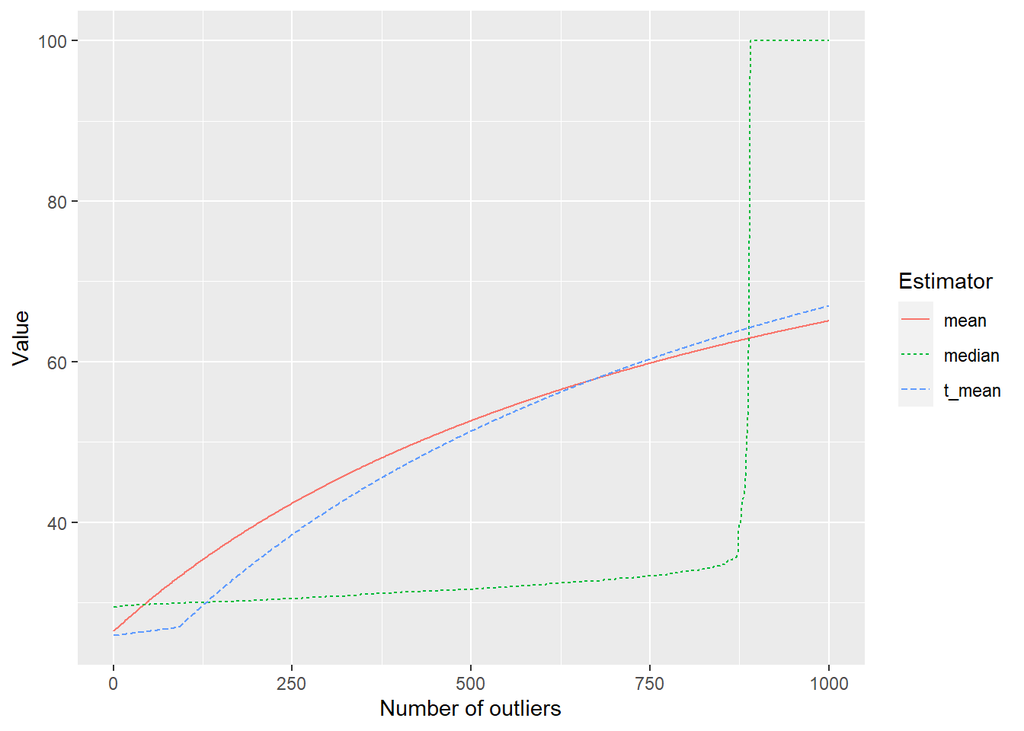

```r
library(tidyr)
library(ggplot2)



df_means_medians <- data.frame(num_outliers=num_outliers_vect, mean=means_vect,
t_mean=t_means_vect, median=medians_vect)

df_means_medians %>%
pivot_longer(!num_outliers, names_to = "Estimator", values_to = "Value") %>%
ggplot(aes(x=num_outliers,color=Estimator, linetype=Estimator,y=Value)) +
geom_line()+xlab("Number of outliers")
```

## 1.5 (Q1)

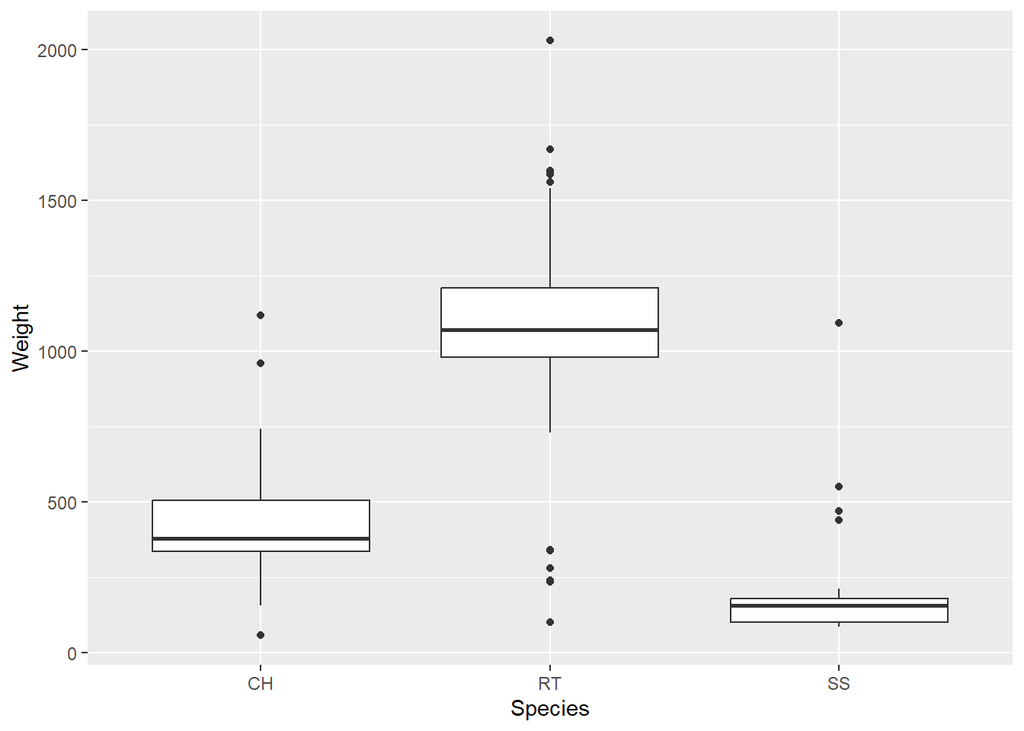

```r
ggplot(data=Hawks,aes(x=Species, y=Weight)) +
geom_boxplot()+xlab("Species") + ylab("Weight")
```

## 1.5 (Q2)

```r
probabilities <- c(0.25, 0.5, 0.75)

quantiles <- Hawks %>%
  select(Weight, Species) %>%
  filter(!is.na(Weight) & is.numeric(Weight)) %>%
  group_by(Species) %>%
  summarize(
    quantile025 = quantile(Weight, probs = probabilities[1], na.rm = TRUE),
    quantile050 = quantile(Weight, probs = probabilities[2], na.rm = TRUE),
    quantile075 = quantile(Weight, probs = probabilities[3], na.rm = TRUE)
  )


quantiles
```

```
## # A tibble: 3 × 4
##   Species quantile025 quantile050 quantile075
##   <fct>         <dbl>       <dbl>       <dbl>
## 1 CH              335        378.        505
## 2 RT              980       1070        1210
## 3 SS              100        155         178.
```

## 1.5 (Q3)

```r
num_outliers <- function(x) {
  q25 <- quantile(x, probs = 0.25, na.rm = TRUE)
  q75 <- quantile(x, probs = 0.75, na.rm = TRUE)
  iqr <- q75 - q25
  outliers <- sum(x < q25 - 1.5 * iqr | x > q75 + 1.5 * iqr, na.rm = TRUE)
  return(outliers)
}

# Test the function
num_outliers(c(0, 40, 60, 185))
```

```
## [1] 1
```

## 1.5 (Q4)

```r
num_outliers_table <- Hawks %>%
  group_by(Species) %>%
  summarise(
    num_outliers_weight = num_outliers(Weight)
  )

num_outliers_table
```

```
## # A tibble: 3 × 2
##   Species num_outliers_weight
##   <fct>                 <int>
## 1 CH                        3
## 2 RT                       13
## 3 SS                        4
```

## 1.6 (Q1)

```r
Covar <- cov(Hawks$Weight, Hawks$Wing, use = "complete.obs")
Corre <- cor(Hawks$Weight, Hawks$Wing, use = "complete.obs")

print(Covar)
```

```
## [1] 41174.39
```

```r
print(Corre)
```

```
## [1] 0.9348575
```

## 1.6 (Q2)

S’ = acS R’ = S/sd(x)*sd(y)

```r
a <- 2.4
b <- 7.1
c <- -1
d <- 3
X <- Hawks$Weight
Y <- Hawks$Wing
X_tilde <- a * Hawks$Weight + b
Y_tilde <- c * Hawks$Wing + d

print(a*c*cov(X, Y,use = "complete.obs"))
```

```
## [1] -98818.54
```

```r
print(cov(X_tilde, Y_tilde,use = "complete.obs"))
```

```
## [1] -98818.54
```

```r
print(cor(X, Y,use = "complete.obs"))
```

```
## [1] 0.9348575
```

```r
print(cor(X_tilde, Y_tilde,use = "complete.obs"))
```

```
## [1] -0.9348575
```

# 2. Random experiments, events and sample spaces, and the set theory

## 2.1 (Q1)

The concepts of random experiments, event, and sample space 1. A random experiment is a procedure (real or imagined) which: a). has a well-defined set of possible outcomes; b). could (at least in principle) be repeated arbitrarily many times. Examples: A coin flip for a coin (outcomes: Heads up, tails up) 2. An event is a set (i.e. a collection) of possible outcomes of an experiment Example: heads up; tails up; heads up or tails up It is important to note that an event is different from a outcome (although an event may contain a single outcome). 3. A sample space is the set of all possible outcomes of interest for a random experiment Example: heads up, tails up

## 2.1 (Q2)

Event: Getting a sum of 7 on the two rolls. This event is represented as {(1, 6), (2, 5), (3, 4), (4, 3), (5, 2), (6, 1)}.

The sample space for this random experiment can be written as a set Ω, which contains all possible outcomes. The sample space Ω in this case consists of all possible pairs of outcomes from two rolls of a six-sided die:

Ω = {(1, 1), (1, 2), (1, 3), (1, 4), (1, 5), (1, 6), (2, 1), (2, 2), …, (6, 5), (6, 6)}, the total number is 36

## 3 (Q1)

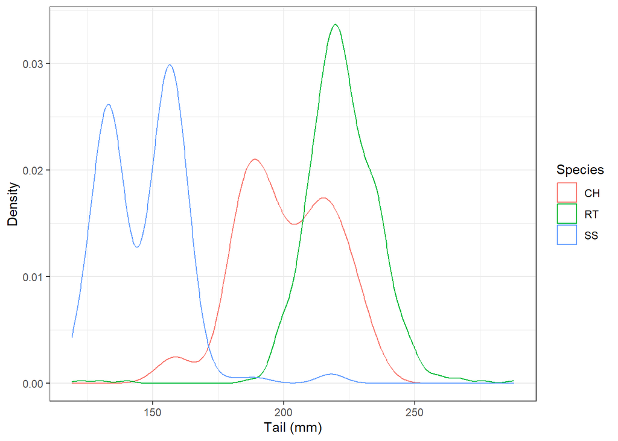

```r
ggplot(data=Hawks, aes(x=Tail, color=Species))+
  geom_density()+theme_bw()+xlab("Tail (mm)")+ylab("Density")
```

## 3 (Q2)

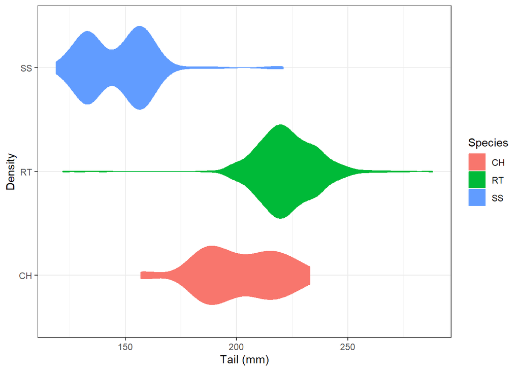

```r
ggplot(data=Hawks, aes(x=Tail, y=Species, color=Species,fill=Species))+geom_violin()+theme_bw()+xlab("Tail (mm)")+ylab("Density")
```

## 3 (Q3)

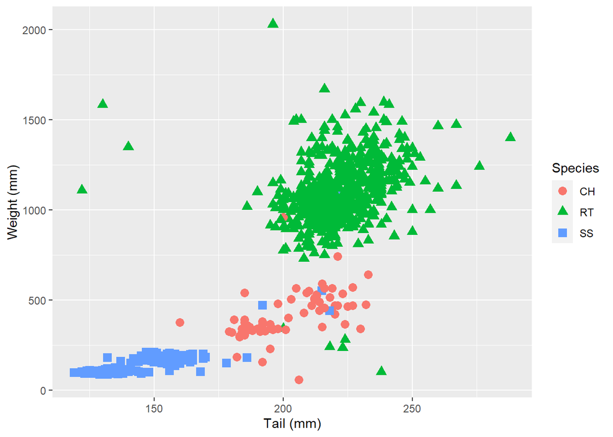

```r
ggplot(data = Hawks, aes(y = Weight, x = Tail, color = Species, shape = Species)) +
  geom_point(size = 3) +
  xlab("Tail (mm)") +
  ylab("Weight (mm)")
```

## 3 (Q4)

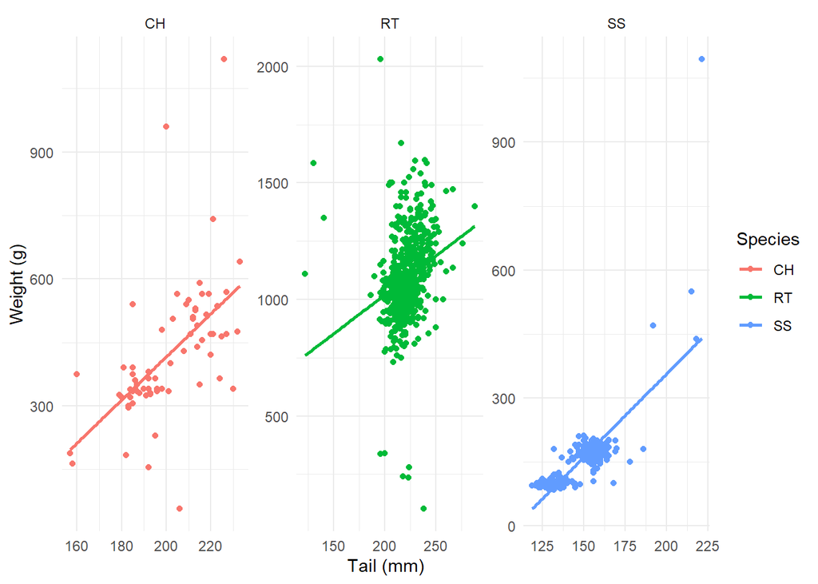

```r
ggplot(data = Hawks, aes(y = Weight, x = Tail, color = Species)) +
  geom_point() +
  geom_smooth(method = "lm", se = FALSE) +
  facet_wrap(~Species, scales = "free") +
  xlab("Tail (mm)") +
  ylab("Weight (g)") +
  theme_minimal()
```